# Project

Nathaniel Zhu

2023-11-06

```r
rm(list=ls())
```

```r
library(caret)
library(gains)
library(pROC)
library(dplyr)
```

```r
library(ggplot2)
library(tidyverse)
library(ggrepel)
library(zoo)
library(randomForest)
library(stringr)
```

#Now first, let us import our data to the dataset:

```r
#Read Data
crime_data <- read.csv("Data/Crime_Data_from_2020_to_Present.csv")
```

#Let’s clean the data by only focusing on victim involved crimes:

```r
#Cleaning Data:
clean_crime_data <- crime_data %>%
  filter(Vict.Sex != "",
         Vict.Descent != "",
         Vict.Age != 0,
         Vict.Sex != "X",
         Vict.Descent != "X"
         )
```

#After we have cleaned the first step of the population. Now, let us set the seed and perform a sampling method of 1000 sample size. Next, let us also drop unnecessary columns in the dataset too.

```r
#Set Seeds
set.seed(123)

#Getting Sample Data with 1000 data rows
sample_data <- clean_crime_data[sample(nrow(clean_crime_data),1000),]

#We want to drop columns that are not very impactful in this dataset analysis
columns_to_drop <- c('DR_NO', 'Rpt.Dist.No', 'Part.1-2', 'Crm.Cd.1', 'Crm.Cd.2', 'Crm.Cd.3', 'Crm.Cd.4', 'Cross.Street', 'Mocodes', 'Part.1.2')

#Drop the Columns
sample_data <- sample_data[, !(names(sample_data) %in% columns_to_drop)]
```

```r
#Set Date Rptd as date
sample_data$Date.Rptd <- as.Date(sample_data$Date.Rptd, format = "%m/%d/%Y %I:%M:%S %p")

#Set DATE.OCC as date
sample_data$DATE.OCC <- as.Date(sample_data$DATE.OCC, format = "%m/%d/%Y %I:%M:%S %p")
```

#Descriptive Analysis: Boxplot

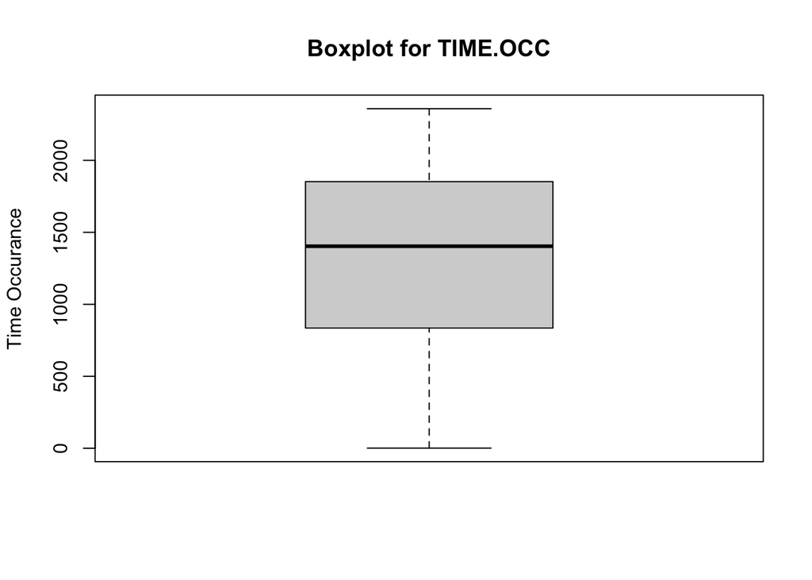

```r
boxplot(sample_data$TIME.OCC,
        main = "Boxplot for TIME.OCC",
        ylab = "Time Occurance")
```

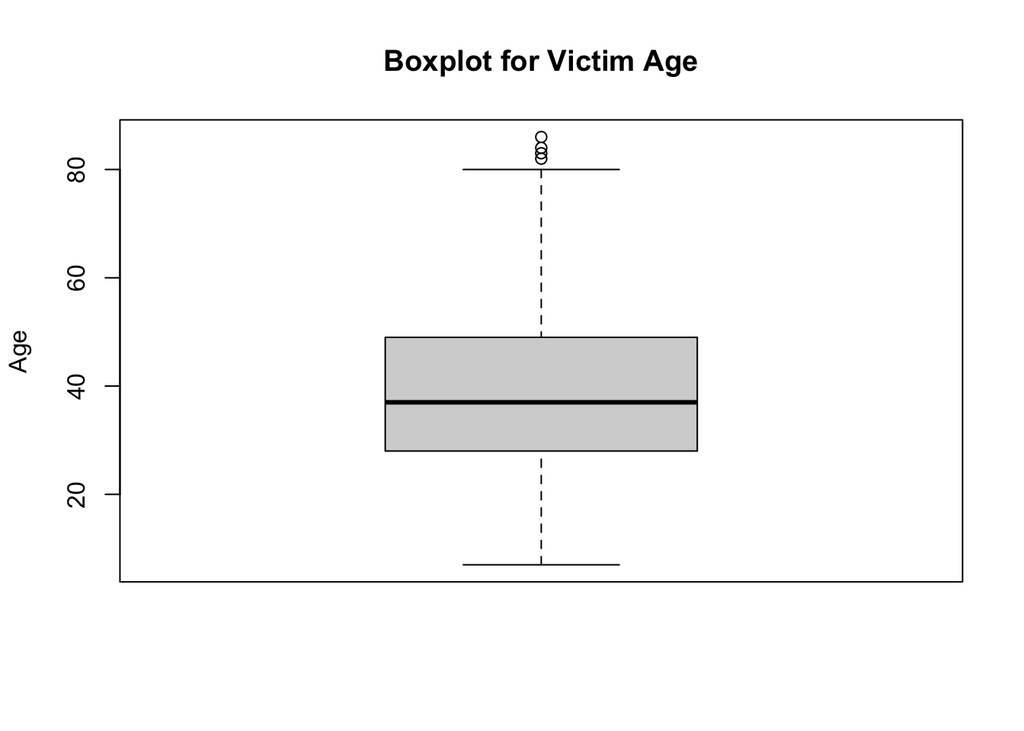

```r
boxplot(sample_data$Vict.Age,
        main = "Boxplot for Victim Age",
        ylab = "Age")
```

#Descriptive analysis: Crime Type Frequency first

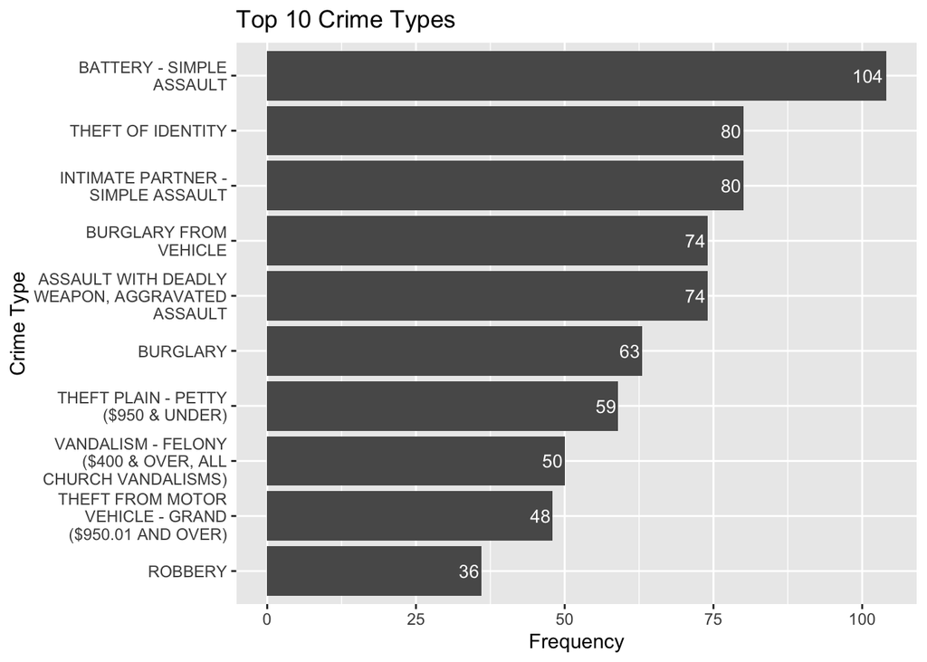

```r
#How many crimes happened in each categories
crime_type_counts <- sample_data %>%
  count(Crm.Cd.Desc) %>%
  arrange(desc(n)) %>%
  head(10)

#Add a column with wrapped text
crime_type_counts$wrapped_desc <- str_wrap(crime_type_counts$Crm.Cd.Desc, width = 20)

#Now, let us make the graph
ggplot(crime_type_counts, aes(x = reorder(wrapped_desc, n), y = n)) +
  geom_bar(stat = "identity") +
  coord_flip() +
  geom_text(aes(label = n), hjust = 1.1, color = "white", size = 3.5) +
  labs(title = "Top 10 Crime Types",
       x = "Crime Type",
       y = "Frequency"
       )
```

#Descriptive Analysis: let us look at the victim sex distribution

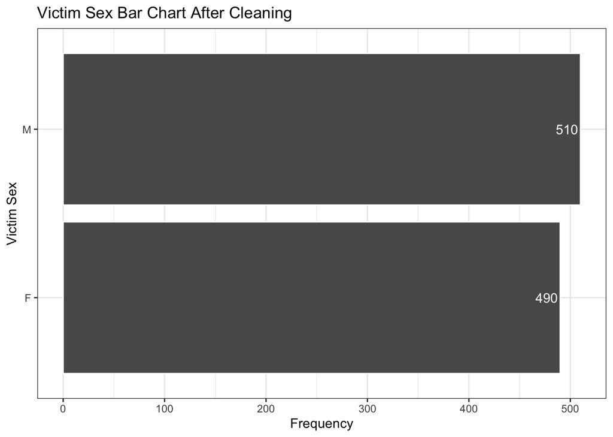

```r
#Counting Crime based on Sex data
crime_sex_counts <- sample_data %>%
  count(Vict.Sex) %>%
  arrange(desc(n))

#Creating GGPlot
ggplot(crime_sex_counts,
       aes(x = reorder(Vict.Sex, n),
           y = n)) +
  geom_bar(stat = "identity", colour = "white") +
  coord_flip() +
  geom_text(aes(label = n), hjust = 1.1, color = "white") +
  labs(title = "Victim Sex Bar Chart After Cleaning",
       x = "Victim Sex",
       y = "Frequency"
       ) +
  theme_bw()
```

#Descriptive Analysis: let us look into the temporal trends in R

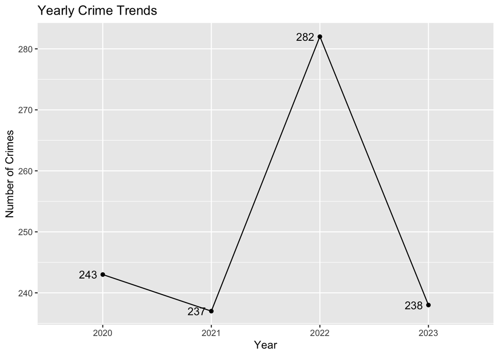

```r
# Extracting year and month from DATE.OCC
sample_data$Month <- format(as.Date(sample_data$DATE.OCC, "%m/%d/%Y"), "%m")
sample_data$Year <- format(as.Date(sample_data$DATE.OCC, "%m/%d/%Y"), "%Y")

#Yearly Trends
yearly_trends <- sample_data %>%
                group_by(Year) %>%
                summarise(Count = n())

#Graphing yearly trends
ggplot(yearly_trends, aes(x = Year, y = Count, group = 1)) +
  geom_line() +
  geom_point() +
  geom_text(aes(label = Count), vjust = 0.5, hjust = 1.3) +
  labs(title = "Yearly Crime Trends",
       x = "Year",
       y = "Number of Crimes"
       )
```

#Descriptive Analysis: Area Analysis in R

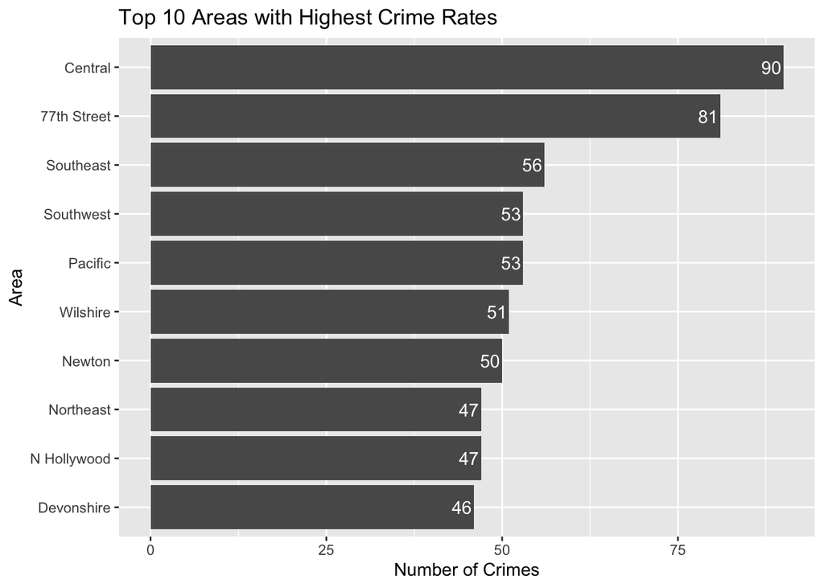

```r
# Counting crimes in each area
area_crime_counts <- sample_data %>%
                     count(AREA.NAME) %>%
                     arrange(desc(n)) %>%
                     head(10)

# Plotting the areas with the highest crime rates
ggplot(area_crime_counts, aes(x=reorder(AREA.NAME, n), y=n)) +
  geom_bar(stat="identity") +
  coord_flip() +
  geom_text(aes(label = n), hjust = 1.1, color = "white") +
  labs(title="Top 10 Areas with Highest Crime Rates", x="Area", y="Number of Crimes")
```

#Descriptive Analysis: Victim Descent Distribution

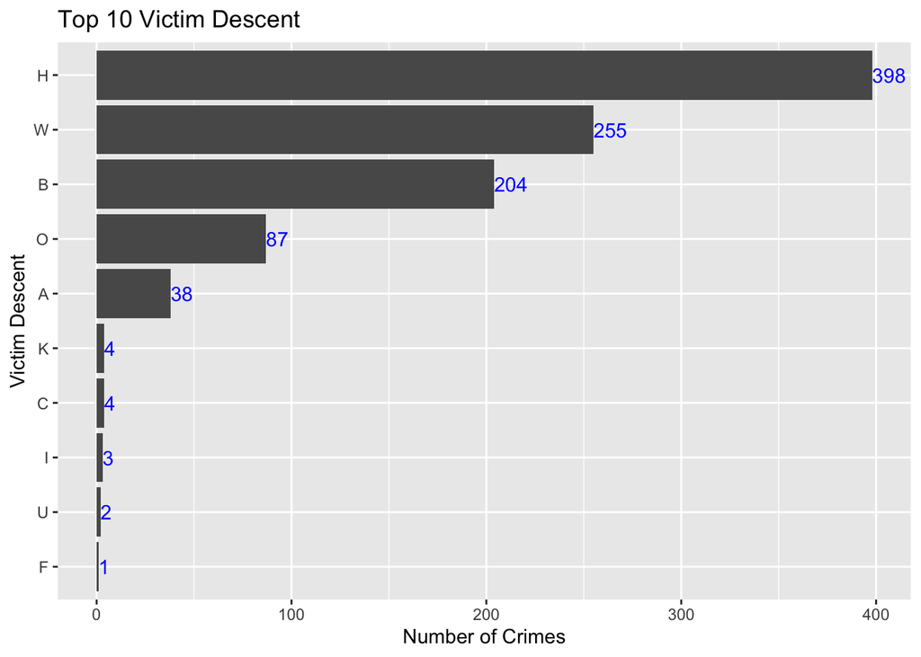

```r
#Analysing the total Victim Descent by Groups
descent_crime_counts <- sample_data %>%
  count(Vict.Descent) %>%
  arrange(desc(n)) %>%
  head(10)

#Creating GGPlot
ggplot(descent_crime_counts,
       aes(x = reorder(Vict.Descent, n),
           y = n)) +
         geom_bar(stat = "identity") +
         coord_flip() +
         geom_text(aes(label = n),hjust = -0.0, color = "blue") +
         labs(title = "Top 10 Victim Descent",
              x = "Victim Descent",
              y = "Number of Crimes"
              )
```

#Time-Series Analysis: Trend Analysis

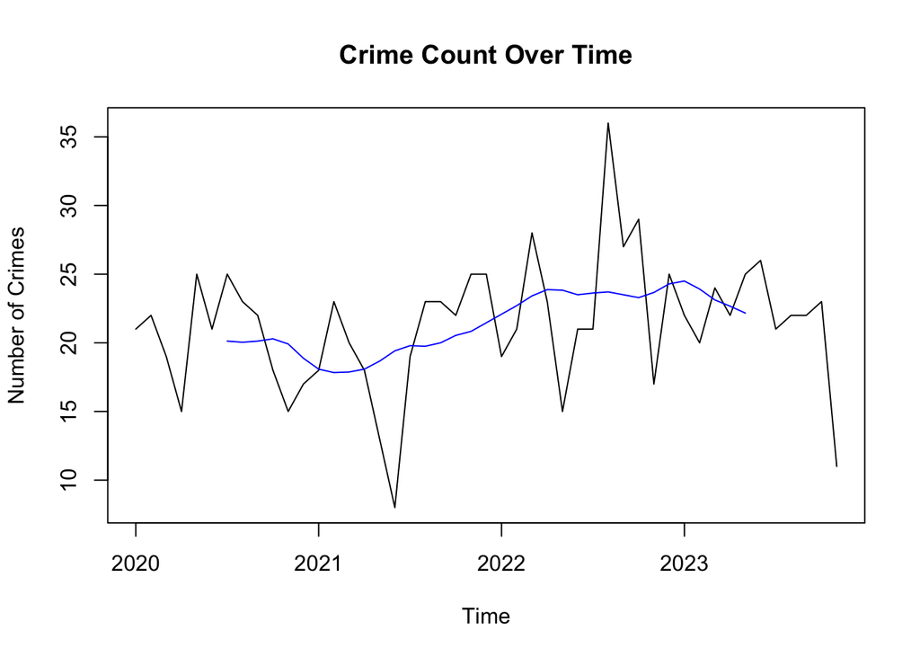

```r
#Let us create a new column called Date with the appropriate Date OCC date
sample_data$Date <- as.Date(sample_data$DATE.OCC, format = "%m/%d/%Y")

#Group and summarize the data
crime_counts_by_date <- sample_data %>%
  mutate(Year = format(Date, "%Y"),
         Month = format(Date, "%m")) %>%
  group_by(Year, Month) %>%
  summarise(Crime_Count = n(), .groups = 'drop')

#Aggregate
crimes_by_month <- sample_data %>%
  group_by(YearMonth = paste(Year, Month, sep = "-")) %>%
  summarise(Crime_Count = n())

#Create a ts objective starting from the first month and year of the dataset
crimes_by_month$YearMonth <- as.yearmon(crimes_by_month$YearMonth, "%Y-%m")

#Create two new Data to use it to plot the time series graph
start_year <- as.numeric(format(min(as.Date(paste(crime_counts_by_date$Year, crime_counts_by_date$Month, "01", sep="-"))), "%Y"))
start_month <- as.numeric(format(min(as.Date(paste(crime_counts_by_date$Year, crime_counts_by_date$Month, "01", sep="-"))), "%m"))


if(length(crime_counts_by_date$Crime_Count) > 0) {
  crime_ts <- ts(crime_counts_by_date$Crime_Count, start=c(start_year, start_month), frequency=12)
}

#Plotting the time series with a simple moving average
plot(crime_ts,
     main = "Crime Count Over Time",
     ylab = "Number of Crimes",
     xlab = "Time"
     )

lines(forecast::ma(crime_ts, order = 12), col="blue")
```

#Time-Series Analysis: Seasonality

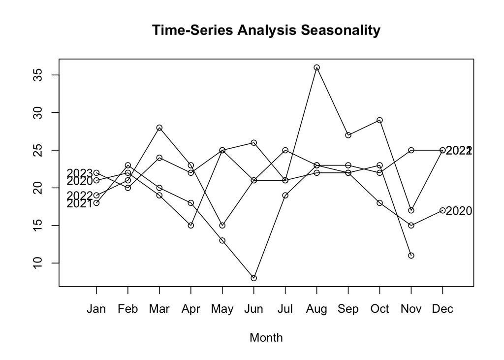

```r
forecast::seasonplot(crime_ts,
                     year.labels=TRUE,
                     year.labels.left=TRUE,
                     main = "Time-Series Analysis Seasonality")
```

#Logistic Regression

```r
set.seed(666)

#Transforming Time OCC into Time_When category for future use
sample_data <- sample_data %>%
  mutate(Time_When = case_when(
    TIME.OCC >= 0 & TIME.OCC < 1200 ~ "Morning",
    TIME.OCC >= 1200 & TIME.OCC < 1800 ~ "Afternoon",
    TIME.OCC >= 1800 & TIME.OCC <= 2400 ~ "Evening",
    TRUE ~ NA_character_
  ))

#Setting out Dependent Variables as dummy variable
sample_data$gender <- ifelse(sample_data$Vict.Sex == "F", 0, 1)
sample_data$gender <- as.factor(sample_data$gender)

#Setting Control
my_lr_Control <- trainControl(method = "cv", number = 10)

#Creating Dummy Variables for our model:
#Creating Dummies for Morning and Afternoon
sample_data$MorningDummy <- ifelse(sample_data$Time_When == "Morning", 1, 0)
sample_data$AfternoonDummy <- ifelse(sample_data$Time_When == "Afternoon", 1, 0)

#Creating Dummy for weapon or not?
sample_data$Weapon_or_not <- ifelse(is.na(sample_data$Weapon.Used.Cd), 0, 1)

#randomly choose 60% of rows for training
lr_train_index <- sample(nrow(sample_data),
                         size = nrow(sample_data)*0.6)
lr_training_sample <- sample_data[lr_train_index,]
lr_validation_sample <- sample_data[-lr_train_index,]


#Model 1 Lets Go
log_model1 <- glm(gender ~ TIME.OCC +
                  AREA +
                  Crm.Cd +
                  Vict.Age +
                  Premis.Cd +
                  Month +
                  Year +
                  MorningDummy +
                  AfternoonDummy +
                  Weapon_or_not,
                data = lr_training_sample,
                family = binomial)

#Use the first model to predict the probabilities of outcomes
predicted_model1_prob <- predict(log_model1,
                                newdata = lr_validation_sample,
                                type = "response")

#Choose a cutoff prob to perform confusionMatrix analysis
predicted_model1_class <- ifelse(predicted_model1_prob > 0.49, 1, 0)

lr_cm1 <- confusionMatrix(as.factor(predicted_model1_class),
                          as.factor(lr_validation_sample$gender),
                          positive = "1")

lr_cm1
```

```
## Confusion Matrix and Statistics
##
##           Reference
## Prediction   0   1
##          0 104 107
##          1  77 112
##
##                Accuracy : 0.54
##                  95% CI : (0.4898, 0.5896)
##     No Information Rate : 0.5475
##     P-Value [Acc > NIR] : 0.63793
##
##                   Kappa : 0.0848
##
##  Mcnemar's Test P-Value : 0.03252
##
##             Sensitivity : 0.5114
##             Specificity : 0.5746
##          Pos Pred Value : 0.5926
##          Neg Pred Value : 0.4929
##              Prevalence : 0.5475
##          Detection Rate : 0.2800
##    Detection Prevalence : 0.4725
##       Balanced Accuracy : 0.5430
##
##        'Positive' Class : 1
##
```

```r
#Let's choose a new logistic model:
log_model2 <- glm(gender ~ TIME.OCC +
                    AREA +
                    Crm.Cd +
                    Vict.Age +
                    Month +
                    Year +
                    MorningDummy +
                    AfternoonDummy +
                    Weapon_or_not,
                  data = lr_training_sample,
                  family = binomial)

#Let us predict the outcomes based on validation sample
predicted_model2_prob <- predict(log_model2,
                                newdata = lr_validation_sample,
                                type = "response")

#Choose a cutoff point of 0.49
predicted_model2_class <- ifelse(predicted_model2_prob > 0.49, 1, 0)

lr_cm2 <- confusionMatrix(as.factor(predicted_model2_class),
                          as_factor(lr_validation_sample$gender),
                          positive = "1")
lr_cm2
```

```
## Confusion Matrix and Statistics
##
##           Reference
## Prediction   0   1
##          0 104 110
##          1  77 109
##
##                Accuracy : 0.5325
##                  95% CI : (0.4823, 0.5822)
##     No Information Rate : 0.5475
##     P-Value [Acc > NIR] : 0.74338
##
##                   Kappa : 0.0712
##
##  Mcnemar's Test P-Value : 0.01928
##
##             Sensitivity : 0.4977
##             Specificity : 0.5746
##          Pos Pred Value : 0.5860
##          Neg Pred Value : 0.4860
##              Prevalence : 0.5475
##          Detection Rate : 0.2725
##    Detection Prevalence : 0.4650
##       Balanced Accuracy : 0.5362
##
##        'Positive' Class : 1
##
```

#KNN

```r
#Setting Seeds
set.seed(666)

#Formatting Time Slot into Time_Slot numeric values
sample_data <- sample_data %>%
  mutate(Time_Slot = case_when(
    TIME.OCC >= 0 & TIME.OCC < 1200 ~ "1",
    TIME.OCC >= 1200 & TIME.OCC < 1800 ~ "2",
    TIME.OCC >= 1800 & TIME.OCC <= 2400 ~ "3",
    TRUE ~ NA_character_
  ))
sample_data$Time_Slot <- as.factor(sample_data$Time_Slot)

#Creating control and grid for KNN
my_knn_Control <- trainControl(method = "cv", number = 10)
my_knn_Grid <- expand.grid(.k = c(1:10))

#Creating Dummies for Morning and Afternoon
sample_data$MorningDummy <- ifelse(sample_data$Time_Slot == "Morning", 1, 0)
sample_data$AfternoonDummy <- ifelse(sample_data$Time_Slot == "Afternoon", 1, 0)

#Creating Dummy for weapon or not?
sample_data$Weapon_or_not <- ifelse(is.na(sample_data$Weapon.Used.Cd), 0, 1)
```

```r
set.seed(666)

#Set Categorical columns to drop
new_columns_to_drop <- c('Date.Rptd', 'DATE.OCC','TIME.OCC','AREA.NAME', 'Crm.Cd.Desc', 'Mocodes', 'Premis.Desc', 'Weapon.Desc', 'Status', 'Status.Desc', 'LOCATION', 'LAT', 'LON', 'Vict.Descent', 'Date', 'Weapon.Used.Cd', 'Vict.Sex', 'Time_When')

#Drop the Columns
numeric_only_data <- sample_data[, !(names(sample_data) %in% new_columns_to_drop)]

#Train Index
numeric_train_index <- sample(nrow(numeric_only_data), size = nrow(numeric_only_data)*0.6)

#Train Sample
numeric_train_sample <- numeric_only_data[numeric_train_index,]

#Validation Sample
numeric_validation_sample <- numeric_only_data[-numeric_train_index,]

#Getting KNN
KNN_ALL <- train(gender ~.,
                 data = numeric_train_sample,
                 method = "knn",
                 trControl = my_knn_Control,
                 tuneGrid = my_knn_Grid
                 )

KNN_ALL
```

```
## k-Nearest Neighbors
##
## 600 samples
##  10 predictor
##   2 classes: '0', '1'
##
## No pre-processing
## Resampling: Cross-Validated (10 fold)
## Summary of sample sizes: 540, 540, 540, 540, 540, 540, ...
## Resampling results across tuning parameters:
##
##   k   Accuracy   Kappa
##    1  0.5300000  0.05909243
##    2  0.5316667  0.06323470
##    3  0.5516667  0.10196557
##    4  0.5433333  0.08424110
##    5  0.5600000  0.11720739
##    6  0.5716667  0.14069452
##    7  0.5633333  0.12329840
##    8  0.5433333  0.08394517
##    9  0.5666667  0.12973312
##   10  0.5600000  0.11624381
##
## Accuracy was used to select the optimal model using the largest value.
## The final value used for the model was k = 6.
```

```r
#Getting Prediction for KNN
KNN_Class <- predict(KNN_ALL,
                     newdata = numeric_validation_sample
                     )

#Confusion Matrix Set Up
confusionMatrix(KNN_Class,
                numeric_validation_sample$gender,
                positive = "1")
```

```
## Confusion Matrix and Statistics
##
##           Reference
## Prediction   0   1
##          0 110 109
##          1  71 110
##
##                Accuracy : 0.55
##                  95% CI : (0.4998, 0.5995)
##     No Information Rate : 0.5475
##     P-Value [Acc > NIR] : 0.480608
##
##                   Kappa : 0.108
##
##  Mcnemar's Test P-Value : 0.005819
##
##             Sensitivity : 0.5023
##             Specificity : 0.6077
##          Pos Pred Value : 0.6077
##          Neg Pred Value : 0.5023
##              Prevalence : 0.5475
##          Detection Rate : 0.2750
##    Detection Prevalence : 0.4525
##       Balanced Accuracy : 0.5550
##
##        'Positive' Class : 1
##
```

```r
#Predicitng Probability
KNN_Class_prob <- predict(KNN_ALL,
                          newdata = numeric_validation_sample,
                          type = "prob"
                          )

head(KNN_Class_prob)
```

|  | 0 | 1 |
| --- | --- | --- |
| 1 | 0.3333333 | 0.6666667 |
| 2 | 0.6666667 | 0.3333333 |
| 3 | 0.0000000 | 1.0000000 |
| 4 | 0.5000000 | 0.5000000 |
| 5 | 0.6666667 | 0.3333333 |
| 6 | 0.5000000 | 0.5000000 |

```r
#Displaying Confusion Matrix for the probability with a cutoff
confusionMatrix(as.factor(ifelse(KNN_Class_prob[,2]>0.49, "1", "0")),
                numeric_validation_sample$gender,
                positive = "1")
```

```
## Confusion Matrix and Statistics
##
##           Reference
## Prediction   0   1
##          0  80  76
##          1 101 143
##
##                Accuracy : 0.5575
##                  95% CI : (0.5073, 0.6068)
##     No Information Rate : 0.5475
##     P-Value [Acc > NIR] : 0.36312
##
##                   Kappa : 0.0961
##
##  Mcnemar's Test P-Value : 0.07124
##
##             Sensitivity : 0.6530
##             Specificity : 0.4420
##          Pos Pred Value : 0.5861
##          Neg Pred Value : 0.5128
##              Prevalence : 0.5475
##          Detection Rate : 0.3575
##    Detection Prevalence : 0.6100
##       Balanced Accuracy : 0.5475
##
##        'Positive' Class : 1
##
```

```r
numeric_validation_sample <- as.numeric(as.character(numeric_validation_sample$gender))
```

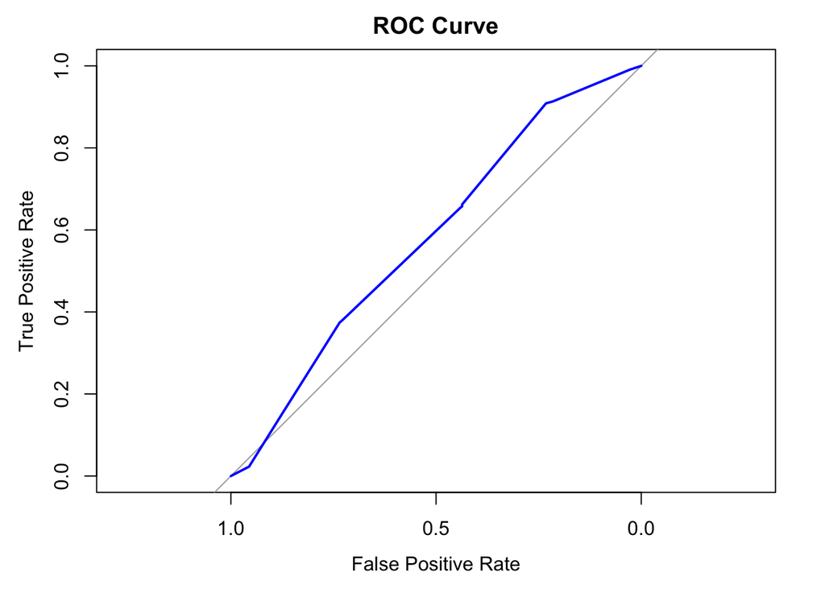

```r
#Displaying ROC Graph
roc_object <- roc(numeric_validation_sample,
                  KNN_Class_prob[,2])
plot.roc(roc_object,
         main = "ROC Curve",
         xlab = "False Positive Rate",
         ylab = "True Positive Rate",
         col = c("blue")
         )
```

```r
auc(roc_object)
```

```
## Area under the curve: 0.5804
```

#IDK IF WE WANT TO USE THIS OR NOT? #Read New Data Excel

```r
new_data <- readxl::read_excel("Data/New_Data.xlsx")
```

#Aggregate Crime Frequency in each Area

```r
crime_counts_by_area <- sample_data %>%
  group_by(AREA) %>%
  summarise(Total_Crimes = n())

crime_counts_by_area
```

| AREA | Total_Crimes |
| --- | --- |
| 1 | 90 |
| 2 | 44 |
| 3 | 53 |
| 4 | 28 |
| 5 | 31 |
| 6 | 46 |
| 7 | 51 |
| 8 | 44 |
| 9 | 46 |
| 10 | 33 |

[output cut: 11 more lines]

#Combine Crime Frequency in each area with new data

```r
frequency_crime_data <- left_join(crime_counts_by_area, new_data, by = "AREA")

cleaned_frequency_crime <- subset(frequency_crime_data, select = -c(AREA, Area_Desc, Zipcode))
cleaned_frequency_crime
```

| Total_Crimes | Median_Income | Population_Density | Total_Population | Unemployment_Rate | Sex_Percentage |
| --- | --- | --- | --- | --- | --- |
| 90 | 31332 | 28540.7 | 8547 | 0.097 | 0.58 |
| 44 | 44607 | 40201.3 | 28433 | 0.060 | 0.55 |
| 53 | 56500 | 17956.2 | 34277 | 0.068 | 0.53 |
| 28 | 49734 | 14332.9 | 47495 | 0.083 | 0.48 |
| 31 | 61144 | 4240.0 | 62647 | 0.065 | 0.49 |
| 46 | 52814 | 19781.8 | 29887 | 0.105 | 0.53 |
| 51 | 54947 | 15759.3 | 61061 | 0.082 | 0.50 |
| 44 | 100453 | 17470.7 | 44608 | 0.063 | 0.49 |
| 46 | 67430 | 10963.4 | 38974 | 0.074 | 0.50 |
| 33 | 68163 | 11921.5 | 78205 | 0.065 | 0.49 |

[output cut: 11 more lines]

#Multiple Linear Regression Model Whole:

```r
frequency_crime_regression <- lm(Total_Crimes ~ .,
                                 data = cleaned_frequency_crime)

summary(frequency_crime_regression)
```

```
##
## Call:
## lm(formula = Total_Crimes ~ ., data = cleaned_frequency_crime)
##
## Residuals:
##      Min       1Q   Median       3Q      Max
## -19.6885  -4.2744  -0.8635   2.1982  27.7903
##
## Coefficients:
##                      Estimate Std. Error t value Pr(>|t|)
## (Intercept)        -4.387e+01  7.058e+01  -0.622    0.544
## Median_Income      -4.657e-05  2.491e-04  -0.187    0.854
## Population_Density  2.176e-04  5.000e-04   0.435    0.670
## Total_Population   -9.636e-05  1.270e-04  -0.758    0.460
## Unemployment_Rate   3.622e+02  2.450e+02   1.478    0.160
## Sex_Percentage      1.360e+02  1.455e+02   0.935    0.365
##
## Residual standard error: 13.12 on 15 degrees of freedom
## Multiple R-squared:  0.4131, Adjusted R-squared:  0.2175
## F-statistic: 2.112 on 5 and 15 DF,  p-value: 0.1204
```

#MLR Model 1

```r
summary(lm(Total_Crimes ~ Median_Income + Total_Population + Sex_Percentage, data = cleaned_frequency_crime))
```

```
##
## Call:
## lm(formula = Total_Crimes ~ Median_Income + Total_Population +
##     Sex_Percentage, data = cleaned_frequency_crime)
##
## Residuals:
##     Min      1Q  Median      3Q     Max
## -18.443  -8.311  -0.022   3.141  32.156
##
## Coefficients:
##                    Estimate Std. Error t value Pr(>|t|)
## (Intercept)      -3.726e+01  6.834e+01  -0.545    0.593
## Median_Income    -2.463e-04  1.679e-04  -1.467    0.161
## Total_Population -5.606e-05  1.237e-04  -0.453    0.656
## Sex_Percentage    2.042e+02  1.224e+02   1.668    0.114
##
## Residual standard error: 13.19 on 17 degrees of freedom
## Multiple R-squared:  0.3275, Adjusted R-squared:  0.2089
## F-statistic:  2.76 on 3 and 17 DF,  p-value: 0.07406
```